[figure not shown]

# IBM Attrition

## Machine Learning Assignment

### Date: 20-Apr-2021 By: Babak Barghi, Alexander Rutten, Will Rains

Assignment Instructions:  
This is a fictional people analytics data set created by IBM data scientists:

https://www.kaggle.com/pavansubhasht/ibm-hr-analytics-attrition-dataset

Your job is to build a model to predict if an employee will leave the company. This is defined by the categorical variable Attrition. The employees leaving the company have a value of Attrition equal to Yes. You can consider several classification models like decision trees, logistic regression or random forests.

You can see how can you implement classification models in:

https://parsnip.tidymodels.org/reference/

Select a good model performing cross validation and tuning hyperparameters on the training set. Once you have defined your model, test its performance on the test set. You must deliver a GroupX.Rmd file, where X is the name of your group. This file will include your analysis, reading the .csv file in the same directory as the file.

### Introduction

In the following report, we used data from *IBM HR Analytics Employee Attrition & Performance*, which includes a total of 35 variables to apply a machine learning method. The goal of this task is to predict Attrition by selecting a set of explanatory variables and building a random forest classification tree.

```r
library(tidyverse)
library(tidymodels)
library(parsnip)
library(ggthemes)
library(skimr)
library(workflows)
library(yardstick)
library(kableExtra)
library(corrplot)
library(RColorBrewer)

knitr::opts_chunk$set(echo = TRUE)
```

### Examine Data

#### Data Importing, Cleaning, Exploration

```r
#Import data
atr_data_raw <- read_csv("WA_Fn-UseC_-HR-Employee-Attrition.csv")
skim(atr_data_raw)
```

Data summary

| Name | atr_data_raw |
| --- | --- |
| Number of rows | 1470 |
| Number of columns | 35 |
| _______________________ |  |
| Column type frequency: |  |
| character | 9 |
| numeric | 26 |
| ________________________ |  |
| Group variables | None |

**Variable type: character**

| skim_variable | n_missing | complete_rate | min | max | empty | n_unique | whitespace |
| --- | --- | --- | --- | --- | --- | --- | --- |
| Attrition | 0 | 1 | 2 | 3 | 0 | 2 | 0 |
| BusinessTravel | 0 | 1 | 10 | 17 | 0 | 3 | 0 |
| Department | 0 | 1 | 5 | 22 | 0 | 3 | 0 |
| EducationField | 0 | 1 | 5 | 16 | 0 | 6 | 0 |
| Gender | 0 | 1 | 4 | 6 | 0 | 2 | 0 |
| JobRole | 0 | 1 | 7 | 25 | 0 | 9 | 0 |
| MaritalStatus | 0 | 1 | 6 | 8 | 0 | 3 | 0 |
| Over18 | 0 | 1 | 1 | 1 | 0 | 1 | 0 |
| OverTime | 0 | 1 | 2 | 3 | 0 | 2 | 0 |

**Variable type: numeric**

| skim_variable | n_missing | complete_rate | mean | sd | p0 | p25 | p50 | p75 | p100 | hist |
| --- | --- | --- | --- | --- | --- | --- | --- | --- | --- | --- |
| Age | 0 | 1 | 36.92 | 9.14 | 18 | 30.00 | 36.0 | 43.00 | 60 | ▂▇▇▃▂ |
| DailyRate | 0 | 1 | 802.49 | 403.51 | 102 | 465.00 | 802.0 | 1157.00 | 1499 | ▇▇▇▇▇ |
| DistanceFromHome | 0 | 1 | 9.19 | 8.11 | 1 | 2.00 | 7.0 | 14.00 | 29 | ▇▅▂▂▂ |
| Education | 0 | 1 | 2.91 | 1.02 | 1 | 2.00 | 3.0 | 4.00 | 5 | ▂▃▇▆▁ |
| EmployeeCount | 0 | 1 | 1.00 | 0.00 | 1 | 1.00 | 1.0 | 1.00 | 1 | ▁▁▇▁▁ |
| EmployeeNumber | 0 | 1 | 1024.87 | 602.02 | 1 | 491.25 | 1020.5 | 1555.75 | 2068 | ▇▇▇▇▇ |
| EnvironmentSatisfaction | 0 | 1 | 2.72 | 1.09 | 1 | 2.00 | 3.0 | 4.00 | 4 | ▅▅▁▇▇ |
| HourlyRate | 0 | 1 | 65.89 | 20.33 | 30 | 48.00 | 66.0 | 83.75 | 100 | ▇▇▇▇▇ |
| JobInvolvement | 0 | 1 | 2.73 | 0.71 | 1 | 2.00 | 3.0 | 3.00 | 4 | ▁▃▁▇▁ |
| JobLevel | 0 | 1 | 2.06 | 1.11 | 1 | 1.00 | 2.0 | 3.00 | 5 | ▇▇▃▂▁ |
| JobSatisfaction | 0 | 1 | 2.73 | 1.10 | 1 | 2.00 | 3.0 | 4.00 | 4 | ▅▅▁▇▇ |
| MonthlyIncome | 0 | 1 | 6502.93 | 4707.96 | 1009 | 2911.00 | 4919.0 | 8379.00 | 19999 | ▇▅▂▁▂ |
| MonthlyRate | 0 | 1 | 14313.10 | 7117.79 | 2094 | 8047.00 | 14235.5 | 20461.50 | 26999 | ▇▇▇▇▇ |
| NumCompaniesWorked | 0 | 1 | 2.69 | 2.50 | 0 | 1.00 | 2.0 | 4.00 | 9 | ▇▃▂▂▁ |
| PercentSalaryHike | 0 | 1 | 15.21 | 3.66 | 11 | 12.00 | 14.0 | 18.00 | 25 | ▇▅▃▂▁ |
| PerformanceRating | 0 | 1 | 3.15 | 0.36 | 3 | 3.00 | 3.0 | 3.00 | 4 | ▇▁▁▁▂ |
| RelationshipSatisfaction | 0 | 1 | 2.71 | 1.08 | 1 | 2.00 | 3.0 | 4.00 | 4 | ▅▅▁▇▇ |
| StandardHours | 0 | 1 | 80.00 | 0.00 | 80 | 80.00 | 80.0 | 80.00 | 80 | ▁▁▇▁▁ |
| StockOptionLevel | 0 | 1 | 0.79 | 0.85 | 0 | 0.00 | 1.0 | 1.00 | 3 | ▇▇▁▂▁ |
| TotalWorkingYears | 0 | 1 | 11.28 | 7.78 | 0 | 6.00 | 10.0 | 15.00 | 40 | ▇▇▂▁▁ |
| TrainingTimesLastYear | 0 | 1 | 2.80 | 1.29 | 0 | 2.00 | 3.0 | 3.00 | 6 | ▂▇▇▂▃ |
| WorkLifeBalance | 0 | 1 | 2.76 | 0.71 | 1 | 2.00 | 3.0 | 3.00 | 4 | ▁▃▁▇▂ |
| YearsAtCompany | 0 | 1 | 7.01 | 6.13 | 0 | 3.00 | 5.0 | 9.00 | 40 | ▇▂▁▁▁ |
| YearsInCurrentRole | 0 | 1 | 4.23 | 3.62 | 0 | 2.00 | 3.0 | 7.00 | 18 | ▇▃▂▁▁ |
| YearsSinceLastPromotion | 0 | 1 | 2.19 | 3.22 | 0 | 0.00 | 1.0 | 3.00 | 15 | ▇▁▁▁▁ |
| YearsWithCurrManager | 0 | 1 | 4.12 | 3.57 | 0 | 2.00 | 3.0 | 7.00 | 17 | ▇▂▅▁▁ |

```r
summary(atr_data_raw)
```

```
##       Age         Attrition         BusinessTravel       DailyRate
##  Min.   :18.00   Length:1470        Length:1470        Min.   : 102.0
##  1st Qu.:30.00   Class :character   Class :character   1st Qu.: 465.0
##  Median :36.00   Mode  :character   Mode  :character   Median : 802.0
##  Mean   :36.92                                         Mean   : 802.5
##  3rd Qu.:43.00                                         3rd Qu.:1157.0
##  Max.   :60.00                                         Max.   :1499.0
##   Department        DistanceFromHome   Education     EducationField
##  Length:1470        Min.   : 1.000   Min.   :1.000   Length:1470
##  Class :character   1st Qu.: 2.000   1st Qu.:2.000   Class :character
##  Mode  :character   Median : 7.000   Median :3.000   Mode  :character
##                     Mean   : 9.193   Mean   :2.913
##                     3rd Qu.:14.000   3rd Qu.:4.000
##                     Max.   :29.000   Max.   :5.000
##  EmployeeCount EmployeeNumber   EnvironmentSatisfaction    Gender
##  Min.   :1     Min.   :   1.0   Min.   :1.000           Length:1470
##  1st Qu.:1     1st Qu.: 491.2   1st Qu.:2.000           Class :character
##  Median :1     Median :1020.5   Median :3.000           Mode  :character
##  Mean   :1     Mean   :1024.9   Mean   :2.722
##  3rd Qu.:1     3rd Qu.:1555.8   3rd Qu.:4.000
##  Max.   :1     Max.   :2068.0   Max.   :4.000
##    HourlyRate     JobInvolvement    JobLevel       JobRole
##  Min.   : 30.00   Min.   :1.00   Min.   :1.000   Length:1470
##  1st Qu.: 48.00   1st Qu.:2.00   1st Qu.:1.000   Class :character
##  Median : 66.00   Median :3.00   Median :2.000   Mode  :character
##  Mean   : 65.89   Mean   :2.73   Mean   :2.064
##  3rd Qu.: 83.75   3rd Qu.:3.00   3rd Qu.:3.000
##  Max.   :100.00   Max.   :4.00   Max.   :5.000
##  JobSatisfaction MaritalStatus      MonthlyIncome    MonthlyRate
##  Min.   :1.000   Length:1470        Min.   : 1009   Min.   : 2094
##  1st Qu.:2.000   Class :character   1st Qu.: 2911   1st Qu.: 8047
##  Median :3.000   Mode  :character   Median : 4919   Median :14236
##  Mean   :2.729                      Mean   : 6503   Mean   :14313
##  3rd Qu.:4.000                      3rd Qu.: 8379   3rd Qu.:20462
##  Max.   :4.000                      Max.   :19999   Max.   :26999
##  NumCompaniesWorked    Over18            OverTime         PercentSalaryHike
##  Min.   :0.000      Length:1470        Length:1470        Min.   :11.00
##  1st Qu.:1.000      Class :character   Class :character   1st Qu.:12.00
##  Median :2.000      Mode  :character   Mode  :character   Median :14.00
##  Mean   :2.693                                            Mean   :15.21
```

[output cut: 8 more lines]

```
##  Max.   :4.000     Max.   :4.000            Max.   :80    Max.   :3.0000
##  TotalWorkingYears TrainingTimesLastYear WorkLifeBalance YearsAtCompany
##  Min.   : 0.00     Min.   :0.000         Min.   :1.000   Min.   : 0.000
##  1st Qu.: 6.00     1st Qu.:2.000         1st Qu.:2.000   1st Qu.: 3.000
##  Median :10.00     Median :3.000         Median :3.000   Median : 5.000
##  Mean   :11.28     Mean   :2.799         Mean   :2.761   Mean   : 7.008
##  3rd Qu.:15.00     3rd Qu.:3.000         3rd Qu.:3.000   3rd Qu.: 9.000
##  Max.   :40.00     Max.   :6.000         Max.   :4.000   Max.   :40.000
##  YearsInCurrentRole YearsSinceLastPromotion YearsWithCurrManager
##  Min.   : 0.000     Min.   : 0.000          Min.   : 0.000
##  1st Qu.: 2.000     1st Qu.: 0.000          1st Qu.: 2.000
##  Median : 3.000     Median : 1.000          Median : 3.000
##  Mean   : 4.229     Mean   : 2.188          Mean   : 4.123
##  3rd Qu.: 7.000     3rd Qu.: 3.000          3rd Qu.: 7.000
##  Max.   :18.000     Max.   :15.000          Max.   :17.000
```

This dataset contains 1470 observations with 35 variables to consider. Using the *summary* and *skim* functions, there is a broad view over the data frame. It is obvious that some of the variables are not useful.

- Employee Count is equal to 1 for all the observations which can not bring value for the analysis.
- Over18 is also equal to ‘Y’ for all the employees that means nobody is less than 18 years old.
- StandardHours is equal to 80 for all the rows.
- EmployeeNumber is only practical for identifying the specific person which is not helpful for the purposes of this analysis.

```r
atr_data <- atr_data_raw
# remove useless variables
atr_data <- atr_data %>% select(-EmployeeCount, -Over18, -StandardHours, -EmployeeNumber)
```

After removing unnecessary variables and having no NA value, it is the time to check on the type of the variables. There are some attributes that are actually categorical, but in the data set are integer. They will be converted to factor in order to avoid numerical assessment.

```r
atr_data <- atr_data %>%
    mutate_if(is.character, as.factor) %>%
    select(Attrition, everything())
```

Also some features are actually factors, even if listed as integers. Thus they will be converted to the right format.

```r
atr_data$Education<- as.factor(atr_data$Education)
atr_data$JobSatisfaction<- as.factor(atr_data$JobSatisfaction)
atr_data$NumCompaniesWorked<- as.factor(atr_data$NumCompaniesWorked)
atr_data$PerformanceRating<- as.factor(atr_data$PerformanceRating)
atr_data$RelationshipSatisfaction<- as.factor(atr_data$RelationshipSatisfaction)
atr_data$StockOptionLevel<- as.factor(atr_data$StockOptionLevel)
atr_data$WorkLifeBalance<- as.factor(atr_data$WorkLifeBalance)
atr_data$EnvironmentSatisfaction<- as.factor(atr_data$EnvironmentSatisfaction)
atr_data$JobInvolvement<- as.factor(atr_data$JobInvolvement)
atr_data$JobLevel<- as.factor(atr_data$JobLevel)
```

#### Data Visualizations

In this part we explore the data set based on the target variable to have a better understanding.

Attrition percentage in general.

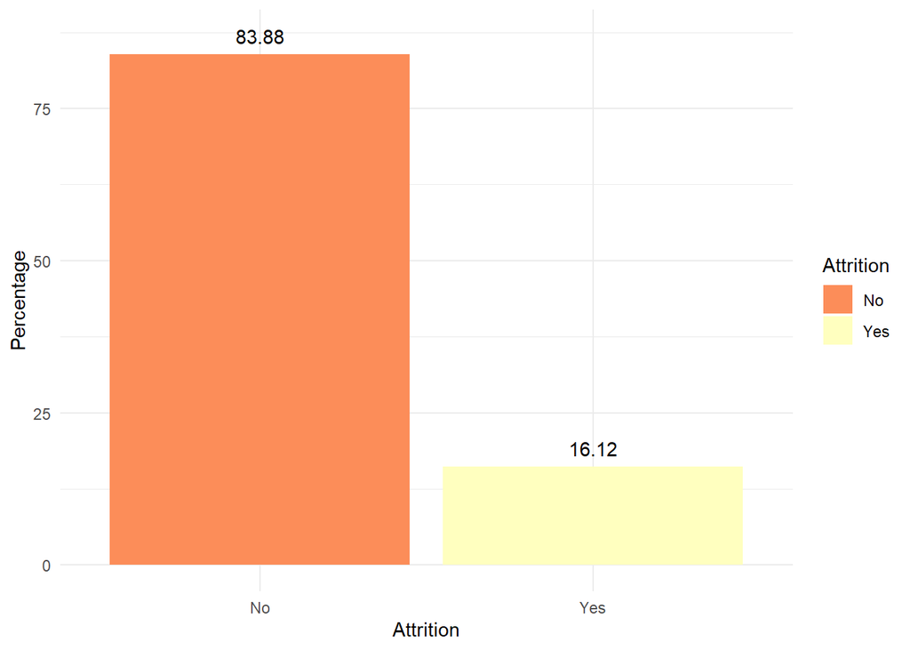

```r
atr_data %>%
  group_by(Attrition) %>%
  summarise(Average = n() / nrow(atr_data)*100) %>%
  ggplot(aes(Attrition, Average, fill = Attrition)) +
  geom_col() +
  ylab("Percentage") +
  geom_text(aes(Attrition, Average + 3, label = round(Average, 2))) +
  scale_fill_brewer(palette = "RdYlBu") +
  theme_minimal()
```

Gender differences in Attrition.

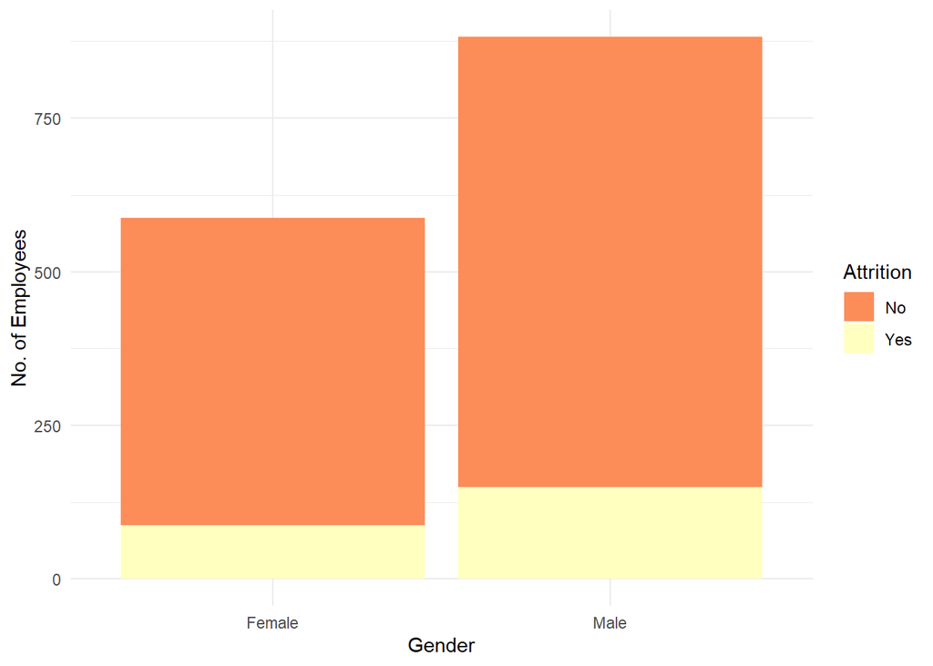

```r
atr_data %>%
  group_by(Gender, Attrition) %>%
  count(Attrition) %>%
  ggplot(aes(x = Gender, y = n, fill = Attrition)) +
  geom_col(position = "stack") +
  labs(
    x = "Gender",
    y = "No. of Employees") +
  scale_fill_brewer(palette = "RdYlBu") +
  theme_minimal()
```

Attrition by Department and average Salary.

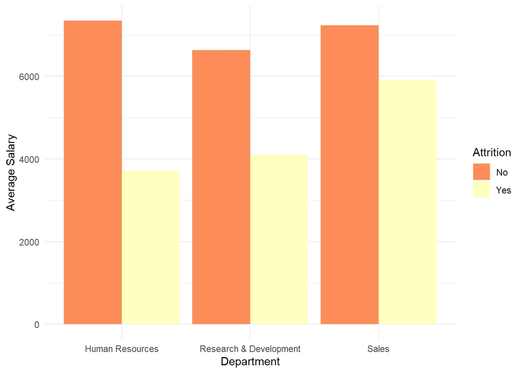

```r
atr_data %>%
  group_by(Attrition, Department) %>%
  summarise(average_salary = mean(MonthlyIncome)) %>%
  ggplot(aes(Department, average_salary, fill = Attrition)) +
  geom_col(position = "dodge") +
  ylab("Average Salary") +
  theme(axis.title.x = element_blank(),
        axis.ticks.x = element_blank()) +
  scale_fill_brewer(palette = "RdYlBu") +
  theme_minimal()
```

Distance from home & Job Role by Attrition.

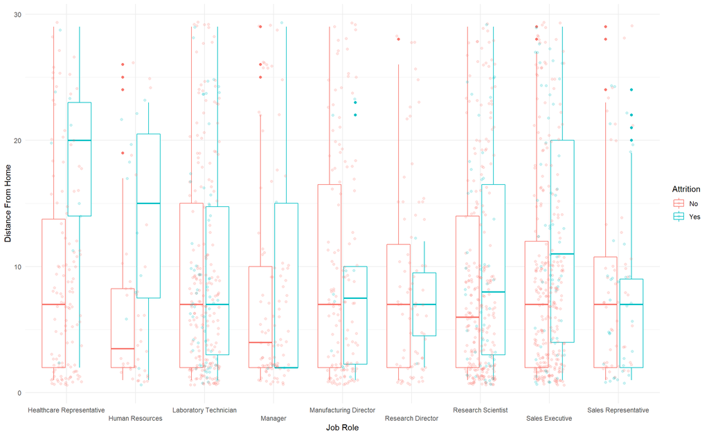

```r
atr_data %>%
  ggplot(aes(x = JobRole, y = DistanceFromHome, color = Attrition)) +
  geom_boxplot() +
  geom_jitter(width=0.22, alpha=0.2) +
  scale_x_discrete(guide = guide_axis(n.dodge=2)) +
  labs(
    y = "Distance From Home",
    x = "Job Role") +
  theme_minimal()
```

Now we will take a look at a corrplot to get an initial indication of correlation within the dataset. For this we have made a few adjustments including changing the attrition variable to a number variable as it is the most important variable to understand correlation with in the dataset

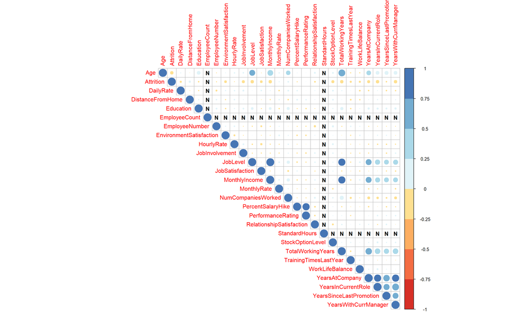

```r
library(corrplot)
library(RColorBrewer)

atr_data_numonly <- atr_data_raw %>%
    mutate(Attrition = case_when(Attrition == 'Yes' ~ 1,
                           Attrition == 'No' ~ 0)) %>%
  select_if(is_numeric)

atr_data_numonly[is.na(atr_data_numonly)] <- 0

acorr <-cor(atr_data_numonly)
corrplot(acorr, type="upper", na.label = "N",
         col=brewer.pal(n=8, name="RdYlBu"))
```

Here you can see that the correlation plot shows that no variable has a particularly strong correlation positively or negatively with attrition suggesting that an advanced algorithm would be needed such as one of machine learning variety to be able to predict much from this dataset for the variable attrition.

### Pre-process/Split Data

The only pre-processing before splitting is changing certain field data types to factors which is needed for modeling and removing some useless fields that may slow down run times and obscure results if kept in the data frame. After these pre-processing steps we will start with defining train and test data frames:

```r
set.seed(42) #split with 0.7 ratio
atr_split <- initial_split(atr_data, prop = 0.7)
training(atr_split) %>% glimpse() #train set
```

```
## Rows: 1,029
## Columns: 31
## $ Attrition                <fct> Yes, No, No, No, No, No, No, No, No, No, No, ~
## $ Age                      <dbl> 41, 33, 27, 32, 59, 38, 36, 35, 29, 31, 34, 2~
## $ BusinessTravel           <fct> Travel_Rarely, Travel_Frequently, Travel_Rare~
## $ DailyRate                <dbl> 1102, 1392, 591, 1005, 1324, 216, 1299, 809, ~
## $ Department               <fct> Sales, Research & Development, Research & Dev~
## $ DistanceFromHome         <dbl> 1, 3, 2, 2, 3, 23, 27, 16, 15, 26, 19, 24, 5,~
## $ Education                <fct> 2, 4, 1, 2, 3, 3, 3, 3, 2, 1, 2, 3, 2, 2, 4, ~
## $ EducationField           <fct> Life Sciences, Life Sciences, Medical, Life S~
## $ EnvironmentSatisfaction  <fct> 2, 4, 1, 4, 3, 4, 3, 1, 4, 1, 2, 3, 1, 4, 1, ~
## $ Gender                   <fct> Female, Female, Male, Male, Female, Male, Mal~
## $ HourlyRate               <dbl> 94, 56, 40, 79, 81, 44, 94, 84, 49, 31, 93, 5~
## $ JobInvolvement           <fct> 3, 3, 3, 3, 4, 2, 3, 4, 2, 3, 3, 2, 4, 4, 2, ~
## $ JobLevel                 <fct> 2, 1, 1, 1, 1, 3, 2, 1, 2, 1, 1, 1, 1, 1, 4, ~
```

[output cut: 18 more lines]

```r
testing(atr_split) %>% glimpse() #test set
```

```
## Rows: 441
## Columns: 31
## $ Attrition                <fct> No, Yes, No, No, No, Yes, Yes, No, Yes, No, N~
## $ Age                      <dbl> 49, 37, 30, 29, 21, 34, 32, 30, 50, 33, 35, 2~
## $ BusinessTravel           <fct> Travel_Frequently, Travel_Rarely, Travel_Rare~
## $ DailyRate                <dbl> 279, 1373, 1358, 1389, 391, 699, 1125, 125, 8~
## $ Department               <fct> Research & Development, Research & Developmen~
## $ DistanceFromHome         <dbl> 8, 2, 24, 21, 15, 6, 16, 9, 3, 1, 4, 2, 12, 5~
## $ Education                <fct> 1, 2, 1, 4, 2, 1, 1, 2, 2, 3, 2, 4, 3, 4, 5, ~
## $ EducationField           <fct> Life Sciences, Other, Life Sciences, Life Sci~
## $ EnvironmentSatisfaction  <fct> 3, 4, 4, 2, 3, 2, 2, 4, 1, 3, 3, 4, 2, 1, 2, ~
## $ Gender                   <fct> Male, Male, Male, Female, Male, Male, Female,~
## $ HourlyRate               <dbl> 61, 92, 67, 51, 96, 83, 72, 83, 86, 42, 75, 3~
## $ JobInvolvement           <fct> 2, 2, 3, 4, 3, 3, 1, 2, 2, 4, 3, 3, 3, 3, 3, ~
## $ JobLevel                 <fct> 2, 1, 1, 3, 1, 1, 1, 1, 1, 2, 1, 1, 5, 2, 2, ~
```

[output cut: 18 more lines]

Next step is to use **recipe** package for data pre-processing.

```r
atr_recipe <- training(atr_split) %>%
  recipe(Attrition ~.) %>%
  step_corr(all_numeric()) %>%
  step_center(all_numeric(), -all_outcomes()) %>%
  step_scale(all_numeric(), -all_outcomes()) %>%
  prep()
atr_recipe
```

```
## Data Recipe
##
## Inputs:
##
##       role #variables
##    outcome          1
##  predictor         30
##
## Training data contained 1029 data points and no missing data.
##
## Operations:
##
## Correlation filter removed no terms [trained]
## Centering for Age, DailyRate, DistanceFromHome, ... [trained]
## Scaling for Age, DailyRate, DistanceFromHome, ... [trained]
```

The recipe has removed no variable.

### Train

#### Define Model, cross validation, tuning hyperparameters

A random forest model is trained using the *ranger* package.

Random forest algorithm was selected for it’s particularly great ability to build classification models that are robust but also remove the particular weakness of other decision tree algorithms in the over-fitting that tends to occur.

```r
atr_ranger <- rand_forest(trees = 1000, mode = "classification") %>%
  set_engine("ranger")
```

Fitting the model

By the *workflows* package we integrate the recipe and the model in a workflow to fit the model using the train set.

```r
atr_ranger_wf <- workflow() %>%
  add_recipe(atr_recipe) %>%
  add_model(atr_ranger) %>%
  fit(training(atr_split))
```

Predicting the train set

```r
atr_pred_train <- atr_ranger_wf %>%
  predict(training(atr_split)) %>%
  bind_cols(training(atr_split))
atr_pred_train %>% glimpse()
```

```
## Rows: 1,029
## Columns: 32
## $ .pred_class              <fct> Yes, No, No, No, No, No, No, No, No, No, No, ~
## $ Attrition                <fct> Yes, No, No, No, No, No, No, No, No, No, No, ~
## $ Age                      <dbl> 41, 33, 27, 32, 59, 38, 36, 35, 29, 31, 34, 2~
## $ BusinessTravel           <fct> Travel_Rarely, Travel_Frequently, Travel_Rare~
## $ DailyRate                <dbl> 1102, 1392, 591, 1005, 1324, 216, 1299, 809, ~
## $ Department               <fct> Sales, Research & Development, Research & Dev~
## $ DistanceFromHome         <dbl> 1, 3, 2, 2, 3, 23, 27, 16, 15, 26, 19, 24, 5,~
## $ Education                <fct> 2, 4, 1, 2, 3, 3, 3, 3, 2, 1, 2, 3, 2, 2, 4, ~
## $ EducationField           <fct> Life Sciences, Life Sciences, Medical, Life S~
## $ EnvironmentSatisfaction  <fct> 2, 4, 1, 4, 3, 4, 3, 1, 4, 1, 2, 3, 1, 4, 1, ~
## $ Gender                   <fct> Female, Female, Male, Male, Female, Male, Mal~
## $ HourlyRate               <dbl> 94, 56, 40, 79, 81, 44, 94, 84, 49, 31, 93, 5~
## $ JobInvolvement           <fct> 3, 3, 3, 3, 4, 2, 3, 4, 2, 3, 3, 2, 4, 4, 2, ~
```

[output cut: 19 more lines]

Now that we have obtained the model it is the time to evaluate the model performance using a confusion matrix.

```r
atr_pred_train %>%
  conf_mat(truth = Attrition, estimate = .pred_class)
```

```
##           Truth
## Prediction  No Yes
##        No  864  39
##        Yes   0 126
```

To evaluate the *specificity* and the *sensitivity*, the following formulas are used:

$$Sensitivity = \frac{TN}{TN+FP}$$
$$Specificity = \frac{TP}{TP+FN}$$

Now we calculate the performance metrics of the model using **metric_set**.

```r
class_metrics <- metric_set(accuracy, precision, recall, sensitivity, specificity)

atr_pred_train %>%
  class_metrics(truth = Attrition, estimate = .pred_class) %>%
  kbl(caption = "Random Forest Model Performance - Train") %>%
    kable_classic(full_width = F)
```

Random Forest Model Performance - Train

| .metric | .estimator | .estimate |
| --- | --- | --- |
| accuracy | binary | 0.9620991 |
| precision | binary | 0.9568106 |
| recall | binary | 1.0000000 |
| sens | binary | 1.0000000 |
| spec | binary | 0.7636364 |

Here we can see that the results of the testing on the training set showed fairly well in that all but the specificity was very high percentages. Further validation needs to be performed on the testing set to make sure that we have not overfitted.

### Validate

Confusion matrix (test set)

We can check for overfitting calculating performance metrics for the test set:

```r
atr_ranger_wf %>%
  predict(testing(atr_split)) %>%
  bind_cols(testing(atr_split)) %>%
  conf_mat(truth = Attrition, estimate = .pred_class)
```

```
##           Truth
## Prediction  No Yes
##        No  369  60
##        Yes   0  12
```

Now we see the metrics for the test set as below.

```r
atr_ranger_wf %>%
  predict(testing(atr_split)) %>%
  bind_cols(testing(atr_split)) %>%
  class_metrics(truth = Attrition, estimate = .pred_class) %>%
  kbl(caption = "Random Forest Model Performance - Test") %>%
      kable_classic(full_width = F)
```

Random Forest Model Performance - Test

| .metric | .estimator | .estimate |
| --- | --- | --- |
| accuracy | binary | 0.8639456 |
| precision | binary | 0.8601399 |
| recall | binary | 1.0000000 |
| sens | binary | 1.0000000 |
| spec | binary | 0.1666667 |

Here we can see that the model when validated against the test set performed worse than against the data in the training set. Particularly the specificity metric.

Below we continue validations with further cross validations

Let’s define a workflow with the atr_recipe and atr_ranger we have previously defined:

```r
atr_ranger_wf <- workflow()  %>%
  add_recipe(atr_recipe) %>%
  add_model(atr_ranger)

#and define a cross-validation with five folds on the training set:

atr_folds <- vfold_cv(training(atr_split), v = 5)

# and perform cross validation:

fit_resamples(atr_ranger_wf, atr_folds) %>%
  collect_metrics()
```

```
## # A tibble: 2 x 6
##   .metric  .estimator  mean     n std_err .config
##   <chr>    <chr>      <dbl> <int>   <dbl> <chr>
## 1 accuracy binary     0.855     5 0.00535 Preprocessor1_Model1
## 2 roc_auc  binary     0.807     5 0.0213  Preprocessor1_Model1
```

### Hyperparameter Tuning

```r
atr_grid <- expand.grid(mtry = c(1,5,10), trees = c(500, 1000, 1500))
atr_grid
```

```
##   mtry trees
## 1    1   500
## 2    5   500
## 3   10   500
## 4    1  1000
## 5    5  1000
## 6   10  1000
## 7    1  1500
## 8    5  1500
## 9   10  1500
```

```r
atr_ranger <- rand_forest(mode = "classification", mtry = tune(), trees = tune()) %>%
  set_engine("ranger")

atr_tune <- tune_grid(object = atr_ranger,
                     preprocessor = atr_recipe,
                     resamples = atr_folds,
                     grid = atr_grid,
                     metrics = metric_set(accuracy, roc_auc))

show_best(atr_tune, metric = "accuracy")
```

```
## # A tibble: 5 x 8
##    mtry trees .metric  .estimator  mean     n std_err .config
##   <dbl> <dbl> <chr>    <chr>      <dbl> <int>   <dbl> <chr>
## 1    10  1500 accuracy binary     0.857     5 0.00362 Preprocessor1_Model9
## 2     5   500 accuracy binary     0.855     5 0.00516 Preprocessor1_Model2
## 3    10   500 accuracy binary     0.855     5 0.00353 Preprocessor1_Model3
## 4    10  1000 accuracy binary     0.855     5 0.00419 Preprocessor1_Model6
## 5     5  1500 accuracy binary     0.854     5 0.00526 Preprocessor1_Model8
```

### Conclusions

Attrition is a very important metric for businesses to monitor. Retraining is very expensively and timely and replacing people can be very difficult particularly if they had a lot of business process knowledge specific to the company.

If an HR department could predict attrition, they could take steps to that person to reduce the likelihood of them leaving or identify the potential causes that might make someone want to leave the company. Even before hiring an employee, if HR can obtain the prediction result that whether this candidate will leave the company soon or will stay for a long time, it will be an efficient method to control the cost and reduce the risk.

We have done just that above. Built a model using the random forest algorithm to predict if someone will leave the company. This methodology and analysis could be of great use to an HR department and is another example of why these methodologies and techniques can be revolutionary in business.